# CTD Validation

Sem

2025-05-22

```r
library(readr)
library(dplyr)
```

```r
library(stringr)
library(purrr)
library(ggplot2)
```

# Introduction

In this .Rmd file, the top-k scoring modules are identified for different scoring algorithms and conditions. For each compound, the Reactome-based enrichment of these modules is compared to the compound enrichment from the Comparative Toxicogenomics Database(CTD) database. Only Reactome pathways were used for this comparison, as it was the only source shared between the module enrichment results and the CTD data. This analysis serves to evaluate the biological relevance of the proposed module scoring methods. It is assessed if there are matches between the databases (0= no match, 1 = 1 or more match). Then the accuracy for the top-k pathways per scoring method and dataset will be computed to evaluate if DRW based scoring provide more biologically accurate results

## CTD data

```r
data_dir <- "C:/Users/semde/Documents/BOO_Scripts/Data/Evaluation"
CTD_Pathways <- read_csv(
  file.path(data_dir, "CTD_Pathways_enriched.csv"),
  skip = 27,
  show_col_types = FALSE
)
```

## PHH data

```r
data_dir <- "C:/Users/semde/Documents/BOO_Scripts/Data/PHH_TXG-MAPr"
module_enrichment_PHH   <- readRDS(file.path(data_dir, "module_enrichment.rds"))
drw_scores_PHH <- readRDS(file.path(data_dir, "drw_scores_PHH_directed.rds"))
eg_scores_PHH <- readRDS(file.path(data_dir, "eg_score.rds"))
#sdrw_scores_PHH <- readRDS(file.path(data_dir, "sdrw_scores_PHH_directed.rds")) # not finished yet
```

## RPTEC data

```r
data_dir <- "C:/Users/semde/Documents/BOO_Scripts/Data/RPTEC_TXG-MAPr"
module_enrichment_RPTEC   <- readRDS(file.path(data_dir, "module_enrichment.rds"))
drw_scores_RPTEC <- readRDS(file.path(data_dir, "drw_scores_RPTEC_r0.7.rds"))
eg_scores_RPTEC <- readRDS(file.path(data_dir, "eg_score.rds"))
#sdrw_scores_RPTEC <- readRDS(file.path(data_dir, "sdrw_scores_RPTEC_directed.rds"))
```

# Preprocessing

## CTD

First row has NA due to weird csv (# in first line)

```r
CTD_Pathways_clean <- CTD_Pathways[-1, ]
```

Reactome is the only match between the module enrichment and CTD

```r
CTD_Pathways_reactome <- CTD_Pathways_clean %>%
  filter(str_starts(PathwayID, "REACT:")) %>%
  filter(CorrectedPValue < 0.05)
```

```r
glimpse(CTD_Pathways_reactome)
```

```
## Rows: 1,047,338
## Columns: 11
## $ `# ChemicalName`   <chr> "10074-G5", "10074-G5", "10074-G5", "10074-G5", "10…
## $ ChemicalID         <chr> "C534883", "C534883", "C534883", "C534883", "C53488…
## $ CasRN              <chr> NA, NA, NA, NA, NA, NA, NA, NA, NA, NA, NA, NA, NA,…
## $ PathwayName        <chr> "Cyclin A:Cdk2-associated events at S phase entry",…
## $ PathwayID          <chr> "REACT:R-HSA-69656", "REACT:R-HSA-69202", "REACT:R-…
## $ PValue             <dbl> 1.43e-05, 1.47e-05, 4.05e-05, 5.85e-05, 4.83e-05, 2…
## $ CorrectedPValue    <dbl> 1.15e-03, 1.18e-03, 3.24e-03, 4.68e-03, 3.86e-03, 2…
## $ TargetMatchQty     <dbl> 2, 2, 2, 2, 2, 2, 2, 3, 3, 3, 2, 2, 2, 2, 2, 2, 2, …
## $ TargetTotalQty     <dbl> 4, 4, 4, 4, 4, 4, 4, 4, 4, 4, 3, 2, 2, 2, 2, 2, 2, …
## $ BackgroundMatchQty <dbl> 71, 72, 119, 143, 130, 30, 101, 349, 100, 44, 252, …
## $ BackgroundTotalQty <dbl> 45555, 45555, 45555, 45555, 45555, 45555, 45555, 45…
```

Filter the reactome code out of the Pathwayname for matching with the RPTEC dataset

```r
CTD_Pathways_reactome <- CTD_Pathways_reactome %>%
  mutate(reactome_id = str_extract(PathwayID, "R-HSA-\\d+"))
```

## PHH

### enrichment df

Only include significantly enriched terms

```r
module_enrichment_PHH <- module_enrichment_PHH %>%
  filter(padj < 0.05)
```

```r
unique(module_enrichment_PHH$source)
```

```
##  [1] "STRING:UniProt"    "STRING:InterPro"   "CPDB:Reactome"
##  [4] "CPDB:Wikipathways" "CPDB:PID"          "CPDB:Signalink"
##  [7] "CPDB:PharmGKB"     "CPDB:BioCarta"     "CPDB:HumanCyc"
## [10] "CPDB:KEGG"         "CPDB:EHMN"         "CPDB:INOH"
## [13] "CPDB:SMPDB"        "CPDB:NetPath"
```

Filter for only reactome terms

```r
module_enrichment_PHH_reactome <- module_enrichment_PHH %>%
  filter(source == "CPDB:Reactome")
```

get the module_number

```r
module_enrichment_PHH_reactome <- module_enrichment_PHH_reactome %>%
  mutate(module_number = str_remove(module, "^hPHH_"),
         module_number = as.integer(module_number))
```

### eg_score df

Strip for module numbers

```r
eg_scores_PHH <- eg_scores_PHH %>%
  mutate(chemical = str_extract(sample_id, "(?<=TG_HPHH_SINGLE_)[^_]+")) %>%
  select(abs_eg_score, chemical, module_number)
```

### drw_score df

```r
drw_scores_PHH <- drw_scores_PHH %>%
  mutate(chemical = str_extract(condition_id, "(?<=TG_HPHH_SINGLE_)[^_]+")) %>%
  mutate(module_number=module_nr) %>%
  select(chemical, drw_zscore, module_number)
```

## RPTEC

```r
module_enrichment_RPTEC <- module_enrichment_RPTEC %>%
  filter(padj < 0.05)
```

```r
unique(module_enrichment_RPTEC$source)
```

```
## [1] "BioCarta_2016"              "KEGG_2021_Human"
## [3] "Reactome_2022"              "WikiPathway_2021_Human"
## [5] "InterPro_Domains_2019"      "GO_Molecular_Function_2023"
## [7] "GO_Cellular_Component_2023" "GO_Biological_Process_2023"
## [9] "HumanCyc_2016"
```

Filter for only reactome terms

```r
module_enrichment_RPTEC_reactome <- module_enrichment_RPTEC %>%
  filter(source == "Reactome_2022")
```

```r
module_enrichment_RPTEC_reactome <- module_enrichment_RPTEC_reactome %>%
  mutate(term_id = str_extract(term, "R-HSA-\\d+"))
```

get the module number

```r
module_enrichment_RPTEC_reactome <- module_enrichment_RPTEC_reactome %>%
  mutate(module_number = str_remove(module, "^hRPTECTERT1_"),
         module_number = as.integer(module_number))
```

### eg_score df

Strip for module numbers

```r
eg_scores_RPTEC <- eg_scores_RPTEC %>%
  mutate(chemical = str_extract(sample_id, "(?<=LU_HRPTECTERT1_SINGLE_)[^_]+")) %>%
  select(abs_eg_score, chemical, module_number)
```

### drw_score df

```r
drw_scores_RPTEC <- drw_scores_RPTEC %>%
  mutate(chemical = str_extract(condition_id, "(?<=LU_HRPTECTERT1_SINGLE_)[^_]+")) %>%
  mutate(module_number=module_nr) %>%
  select(chemical, drw_zscore, module_number)
```

# Seeing if there are matches

To see if this analysis is possible, it was first checked to see if there are matches.

For PHH matching needs to be done on strings, which makes it less good. But there are no reactome codes available.

```r
# 1. Extract the two name‐vectors
ctd_names   <- CTD_Pathways_reactome$PathwayName
phh_names   <- module_enrichment_PHH_reactome$term

# 2. Find exact overlaps
common_names <- intersect(ctd_names, phh_names)

# 3. Subset the enrichment table to only those matches
matches_df_PHH <- module_enrichment_PHH %>%
  filter(term %in% common_names)
```

```r
nrow(matches_df_PHH)
```

```
## [1] 1610
```

For RPTEC matching could be done on R-HSA code.

```r
ctd_ids   <- CTD_Pathways_reactome$reactome_id
rptec_ids <- module_enrichment_RPTEC_reactome$term_id

# Find common id
common_ids <- intersect(ctd_ids, rptec_ids)

matches_df_RPTEC <- module_enrichment_RPTEC_reactome %>%
  filter(term_id %in% common_ids)
```

```r
nrow(matches_df_RPTEC)
```

```
## [1] 3286
```

# PHH analysis

## Preprocessing (again)

First, the chemicals from TXG-MAPr have to match the chemical for the CTD database. This was manually done for the top k pathways

### Arranging the CTD

arranging the ctd database for manual mapping of the chemicals.

```r
CTD_chemicals_unique <- CTD_Pathways_reactome %>%
  arrange(`# ChemicalName`) %>%
  distinct(`# ChemicalName`, .keep_all = TRUE)
```

### eg_score

```r
eg_scores_PHH %>%
  arrange(desc(abs_eg_score)) %>%
  head(100)
```

```
## # A tibble: 100 × 3
##    abs_eg_score chemical                      module_number
##           <dbl> <chr>                                 <dbl>
##  1         24.3 DOXORUBICIN                             126
##  2         20.1 PAPAVERINE                               51
##  3         20.1 VALPROICACID                             31
##  4         16.6 CYCLOHEXIMIDE                            73
##  5         16.1 INTERFERONALPHAHUMAN                     12
##  6         15.8 CYCLOHEXIMIDE                           150
##  7         15.6 INTERFERONALPHAHUMAN                     12
##  8         15.4 DOXORUBICIN                             117
##  9         15.0 DOXORUBICIN                             264
## 10         14.5 TRANSFORMINGGROWTHFACTORBETA1            29
## # ℹ 90 more rows
```

```r
eg_scores_PHH <- eg_scores_PHH %>%
  mutate(chemical_ctd = case_when(
    chemical == "DOXORUBICIN"     ~ "Doxorubicin",
    chemical == "PAPAVERINE"  ~ "Papaverine",
    chemical == "VALPROICACID"    ~ "Valproic Acid",
    chemical == "CYCLOHEXIMIDE"    ~ "Cycloheximide",
    chemical == "INTERFERONALPHAHUMAN" ~ "Interferon-alpha",
    chemical == "TRANSFORMINGGROWTHFACTORBETA1" ~ "Transforming Growth Factor beta1",
    chemical == "ETHIONINE" ~ "Ethionine",
    chemical == "PHENOBARBITAL" ~ "Phenobarbital",
    chemical == "CAFFEINE" ~ "Caffeine",
    chemical == "BROMOETHYLAMINE" ~ "2-bromoethylamine",
    chemical == "ALLYLALCOHOL" ~ "allyl alcohol",
    chemical == "NEFAZODONE" ~ "nefazodone",
    chemical == "THEOPHYLLINE" ~ "Theophylline",
    chemical == "PHALLOIDIN" ~ "Phalloidine",
    chemical == "OMEPRAZOLE" ~ "Omeprazole",
    chemical == "SULINDAC" ~ "Sulindac",
    chemical == "COLCHICINE" ~ "Colchicine",
    chemical == "AFLATOXINB1" ~ "Aflatoxin B1",
    chemical == "NMETHYLNNITROSOUREA" ~ "Methylnitrosourea",
    chemical == "TNFALPHARAT" ~ "Tumor Necrosis Factors",
    TRUE ~ chemical  # fallback to original if no match
  ))
```

```r
eg_scores_PHH %>%
  arrange(desc(abs_eg_score)) %>%
  head(100)
```

```
## # A tibble: 100 × 4
##    abs_eg_score chemical                      module_number chemical_ctd
##           <dbl> <chr>                                 <dbl> <chr>
##  1         24.3 DOXORUBICIN                             126 Doxorubicin
##  2         20.1 PAPAVERINE                               51 Papaverine
##  3         20.1 VALPROICACID                             31 Valproic Acid
##  4         16.6 CYCLOHEXIMIDE                            73 Cycloheximide
##  5         16.1 INTERFERONALPHAHUMAN                     12 Interferon-alpha
##  6         15.8 CYCLOHEXIMIDE                           150 Cycloheximide
##  7         15.6 INTERFERONALPHAHUMAN                     12 Interferon-alpha
##  8         15.4 DOXORUBICIN                             117 Doxorubicin
##  9         15.0 DOXORUBICIN                             264 Doxorubicin
## 10         14.5 TRANSFORMINGGROWTHFACTORBETA1            29 Transforming Growth…
## # ℹ 90 more rows
```

```r
top100_results_PHH_eg <- eg_scores_PHH %>%
  arrange(desc(abs_eg_score)) %>%
  slice_head(n = 100) %>%
  transmute(chemical_ctd,
            module_nr = module_number,
            abs_eg_score) %>%    # renaming because of joining problems
  rowwise() %>%
  mutate(
    module_terms = list(
      module_enrichment_PHH_reactome %>%
        filter(
          module_number == module_nr,
          source        == "CPDB:Reactome", # already did this but just to be sure
          padj          <  0.05 # same
        ) %>%
        pull(term) %>%
        unique()
    ),
    ctd_terms = list(
      CTD_Pathways_reactome %>%
        filter(
          `# ChemicalName` == chemical_ctd,
          CorrectedPValue  <  0.05
        ) %>%
        pull(PathwayName) %>%
        unique()
    ),
    overlaps  = list(intersect(module_terms, ctd_terms)),
    n_matches = length(overlaps),
    has_match = as.integer(n_matches > 0)
  ) %>%
  ungroup() %>%
  select(chemical_ctd,
         module_number = module_nr,
         n_matches,
         has_match,
         abs_eg_score)
```

```r
print(top100_results_PHH_eg)
```

```
## # A tibble: 100 × 5
##    chemical_ctd                   module_number n_matches has_match abs_eg_score
##    <chr>                                  <dbl>     <int>     <int>        <dbl>
##  1 Doxorubicin                              126         0         0         24.3
##  2 Papaverine                                51         1         1         20.1
##  3 Valproic Acid                             31         2         1         20.1
##  4 Cycloheximide                             73         4         1         16.6
##  5 Interferon-alpha                          12         7         1         16.1
##  6 Cycloheximide                            150         0         0         15.8
##  7 Interferon-alpha                          12         7         1         15.6
##  8 Doxorubicin                              117         0         0         15.4
##  9 Doxorubicin                              264         0         0         15.0
## 10 Transforming Growth Factor be…            29         0         0         14.5
## # ℹ 90 more rows
```

### drw_score

```r
drw_scores_PHH %>%
  arrange(desc(drw_zscore)) %>%
  head(50)
```

```
## # A tibble: 50 × 3
##    chemical               drw_zscore module_number
##    <chr>                       <dbl>         <dbl>
##  1 OMEPRAZOLE                   2.20           358
##  2 OMEPRAZOLE                   2.00           358
##  3 OMEPRAZOLE                   1.56           358
##  4 ISONIAZID                    1.50           358
##  5 2NITROFLUORENE               1.49           358
##  6 OMEPRAZOLE                   1.44           358
##  7 HEXACHLOROBENZENE            1.43           358
##  8 SULINDAC                     1.37           358
##  9 ACETAMIDOFLUORENE            1.35           358
## 10 NAPHTHYLISOTHIOCYANATE       1.28           358
## # ℹ 40 more rows
```

```r
drw_scores_PHH <- drw_scores_PHH %>%
  mutate(chemical_ctd = case_when(
    chemical == "OMEPRAZOLE"     ~ "Omeprazole",
    chemical == "ISONIAZID"  ~ "Isoniazid",
    chemical == "2NITROFLUORENE"    ~ "2-nitrofluorene",
    chemical == "HEXACHLOROBENZENE" ~ "Hexachlorobenzene",
    chemical == "SULINDAC" ~ "Sulindac",
    chemical == "ACETAMIDOFLUORENE" ~ "4-acetylaminofluorene",
    chemical == "FLUTAMIDE" ~ "Flutamide",
    chemical == "MEXILETINE" ~ "Mexiletine",
    chemical == "PHALLOIDIN" ~ "Phalloidine",
    chemical == "ALLYLALCOHOL" ~ "allyl alcohol",
    chemical == "DOXORUBICIN" ~ "Doxorubicin",
    chemical == "NIFEDIPINE" ~ "Nifedipine",
    chemical == "TNFALPHARAT" ~ "Tumor Necrosis Factors",
    chemical == "CYCLOHEXIMIDE" ~ "Cycloheximide",
    chemical == "ACETAMINOPHEN" ~ "Acetaminophen",
    chemical == "ETHIONINE" ~ "Ethionine",
    chemical == "INTERLEUKIN1BETAHUMAN" ~ "Interleukins",
    chemical == "COLCHICINE" ~ "Colchicine",
    chemical == "NAPROXEN" ~ "Naproxen",
    chemical == "THEOPHYLLINE" ~ "Theophylline",
    chemical == "VALPROICACID"    ~ "Valproic Acid",
    chemical == "METHAPYRILENE" ~ "Methapyrilene",
    chemical == "ROSIGLITAZONEMALEATE" ~ "Rosiglitazone",
    chemical == "KETOCONAZOLE" ~ "Ketoconazole",
    chemical == "PHENYLBUTAZONE" ~ "Phenylbutazone",
    chemical == "NAPHTHYLISOTHIOCYANATE" ~ "1-Naphthylisothiocyanate",
    chemical == "INTERFERONALPHAHUMAN" ~ "Interferon alpha-2",
    chemical == "PROPYLTHIOURACIL" ~ "Propylthiouracil",
    chemical == "MOXISYLYTE" ~ "Moxisylyte",
    chemical == "DICLOFENAC" ~ "Diclofenac",
    chemical == "NMETHYLNNITROSOUREA" ~ "Methylnitrosourea",
    chemical == "RIFAMPICIN" ~ "Rifampin",
    chemical == "CARBAMAZEPINE" ~ "Carbamazepine",
    chemical == "DIETHYLMALEATE" ~ "diethyl maleate",
    chemical == "PHENOBARBITAL" ~ "Phenobarbital",
    chemical == "FLUPHENAZINE" ~ "Fluphenazine",
    chemical == "PAPAVERINE" ~ "Papaverine",
    chemical == "CAFFEINE" ~ "Caffeine",
    chemical == "FUROSEMIDE" ~ "Furosemide",
    chemical == "NIMESULIDE" ~ "nimesulide",
    TRUE ~ chemical  # fallback to original if no match
  ))
```

```r
drw_scores_PHH %>%
  arrange(desc(drw_zscore)) %>%
  head(100)
```

```
## # A tibble: 100 × 4
##    chemical               drw_zscore module_number chemical_ctd
##    <chr>                       <dbl>         <dbl> <chr>
##  1 OMEPRAZOLE                   2.20           358 Omeprazole
##  2 OMEPRAZOLE                   2.00           358 Omeprazole
##  3 OMEPRAZOLE                   1.56           358 Omeprazole
##  4 ISONIAZID                    1.50           358 Isoniazid
##  5 2NITROFLUORENE               1.49           358 2-nitrofluorene
##  6 OMEPRAZOLE                   1.44           358 Omeprazole
##  7 HEXACHLOROBENZENE            1.43           358 Hexachlorobenzene
##  8 SULINDAC                     1.37           358 Sulindac
##  9 ACETAMIDOFLUORENE            1.35           358 4-acetylaminofluorene
## 10 NAPHTHYLISOTHIOCYANATE       1.28           358 1-Naphthylisothiocyanate
## # ℹ 90 more rows
```

```r
top100_results_PHH_drw <- drw_scores_PHH %>%
  arrange(desc(drw_zscore)) %>%
  slice_head(n = 100) %>%
  transmute(chemical_ctd,
            module_nr = module_number,
            drw_zscore) %>%    # joining problems
  rowwise() %>%
  mutate(
    module_terms = list(
      module_enrichment_PHH_reactome %>%
        filter(
          module_number == module_nr,
          source        == "CPDB:Reactome", # to be sure
          padj          <  0.05
        ) %>%
        pull(term) %>%
        unique()
    ),
    ctd_terms = list(
      CTD_Pathways_reactome %>%
        filter(
          `# ChemicalName` == chemical_ctd,
          CorrectedPValue  <  0.05
        ) %>%
        pull(PathwayName) %>%
        unique()
    ),
    overlaps  = list(intersect(module_terms, ctd_terms)),
    n_matches = length(overlaps),
    has_match = as.integer(n_matches > 0)
  ) %>%
  ungroup() %>%
  select(chemical_ctd,
         module_number = module_nr,
         n_matches,
         has_match,
         drw_zscore)
```

```r
print(top100_results_PHH_drw)
```

```
## # A tibble: 100 × 5
##    chemical_ctd             module_number n_matches has_match drw_zscore
##    <chr>                            <dbl>     <int>     <int>      <dbl>
##  1 Omeprazole                         358         7         1       2.20
##  2 Omeprazole                         358         7         1       2.00
##  3 Omeprazole                         358         7         1       1.56
##  4 Isoniazid                          358         7         1       1.50
##  5 2-nitrofluorene                    358         2         1       1.49
##  6 Omeprazole                         358         7         1       1.44
##  7 Hexachlorobenzene                  358         7         1       1.43
##  8 Sulindac                           358         4         1       1.37
##  9 4-acetylaminofluorene              358         2         1       1.35
## 10 1-Naphthylisothiocyanate           358         6         1       1.28
## # ℹ 90 more rows
```

# RPTEC Analysis

## eg scores

```r
eg_scores_RPTEC %>%
  arrange(desc(abs_eg_score)) %>%
  head(100)
```

```
## # A tibble: 100 × 3
##    abs_eg_score chemical         module_number
##           <dbl> <chr>                    <dbl>
##  1        12.3  ARISTOLOCHICACID           198
##  2         9.06 ARISTOLOCHICACID            11
##  3         8.70 LEADACETATE                264
##  4         8.61 DOXORUBICIN                 63
##  5         8.46 ARISTOLOCHICACID            11
##  6         8.20 DOXORUBICIN                 63
##  7         7.97 DOXORUBICIN                166
##  8         7.88 OCHRATOXINA                  3
##  9         7.81 OCHRATOXINA                  3
## 10         7.74 DOXORUBICIN                117
## # ℹ 90 more rows
```

```r
eg_scores_RPTEC <- eg_scores_RPTEC %>%
  mutate(chemical_ctd = case_when(
    chemical == "DOXORUBICIN" ~ "Doxorubicin",
    chemical == "ARISTOLOCHICACID" ~ "Aristolochic Acids",
    chemical == "LEADACETATE" ~ "lead acetate",
    chemical == "OCHRATOXINA" ~ "ochratoxin A",
    chemical == "MITOMYCINC" ~ "Mitomycin",
    chemical == "CYCLOSPORINA" ~ "Cyclosporins",
    chemical == "RAPAMYCIN" ~ "Sirolimus",
    chemical == "CISPLATIN" ~ "Cisplatin",
    chemical == "ZOLENDRONICACID" ~ "Zoledronic Acid",
    TRUE ~ chemical  # fallback to original if no match
  ))
```

```r
eg_scores_RPTEC %>%
  arrange(desc(abs_eg_score)) %>%
  head(100)
```

```
## # A tibble: 100 × 4
##    abs_eg_score chemical         module_number chemical_ctd
##           <dbl> <chr>                    <dbl> <chr>
##  1        12.3  ARISTOLOCHICACID           198 Aristolochic Acids
##  2         9.06 ARISTOLOCHICACID            11 Aristolochic Acids
##  3         8.70 LEADACETATE                264 lead acetate
##  4         8.61 DOXORUBICIN                 63 Doxorubicin
##  5         8.46 ARISTOLOCHICACID            11 Aristolochic Acids
##  6         8.20 DOXORUBICIN                 63 Doxorubicin
##  7         7.97 DOXORUBICIN                166 Doxorubicin
##  8         7.88 OCHRATOXINA                  3 ochratoxin A
##  9         7.81 OCHRATOXINA                  3 ochratoxin A
## 10         7.74 DOXORUBICIN                117 Doxorubicin
## # ℹ 90 more rows
```

```r
top100_results_RPTEC_eg <- eg_scores_RPTEC %>%
  arrange(desc(abs_eg_score)) %>%
  slice_head(n = 100) %>%
  transmute(chemical_ctd,
            module_nr = module_number,
            abs_eg_score) %>%    # joining problems
  rowwise() %>%
  mutate(
    module_terms = list(
      module_enrichment_RPTEC_reactome %>%
        filter(
          module_number == module_nr,        # to be sure
          source        == "Reactome_2022",
          padj          <  0.05
        ) %>%
        pull(term_id) %>%
        unique()
    ),
    ctd_terms = list(
      CTD_Pathways_reactome %>%
        filter(
          `# ChemicalName` == chemical_ctd,
          CorrectedPValue  <  0.05
        ) %>%
        pull(reactome_id) %>%
        unique()
    ),
    overlaps  = list(intersect(module_terms, ctd_terms)),
    n_matches = length(overlaps),
    has_match = as.integer(n_matches > 0)
  ) %>%
  ungroup() %>%
  select(chemical_ctd,
         module_number = module_nr,
         n_matches,
         has_match,
         abs_eg_score)
```

```r
print(top100_results_RPTEC_eg)
```

```
## # A tibble: 100 × 5
##    chemical_ctd       module_number n_matches has_match abs_eg_score
##    <chr>                      <dbl>     <int>     <int>        <dbl>
##  1 Aristolochic Acids           198         0         0        12.3
##  2 Aristolochic Acids            11         0         0         9.06
##  3 lead acetate                 264        12         1         8.70
##  4 Doxorubicin                   63         2         1         8.61
##  5 Aristolochic Acids            11         0         0         8.46
##  6 Doxorubicin                   63         2         1         8.20
##  7 Doxorubicin                  166         1         1         7.97
##  8 ochratoxin A                   3         2         1         7.88
##  9 ochratoxin A                   3         2         1         7.81
## 10 Doxorubicin                  117         2         1         7.74
## # ℹ 90 more rows
```

## DRW scores

```r
drw_scores_RPTEC %>%
  arrange(desc(drw_zscore)) %>%
  head(100)
```

```
## # A tibble: 100 × 3
##    chemical         drw_zscore module_number
##    <chr>                 <dbl>         <dbl>
##  1 INTERLEUKIN1BETA       2.52           241
##  2 INTERLEUKIN1BETA       2.46           241
##  3 INTERLEUKIN1BETA       2.43           241
##  4 LEADACETATE            2.38           264
##  5 MITOMYCINC             2.30           289
##  6 ZOLENDRONICACID        2.09           222
##  7 RAPAMYCIN              1.98           275
##  8 RAPAMYCIN              1.74           290
##  9 AMPHOTERICINB          1.72           241
## 10 AMPHOTERICINB          1.72           241
## # ℹ 90 more rows
```

```r
drw_scores_RPTEC <- drw_scores_RPTEC %>%
  mutate(chemical_ctd = case_when(
    chemical == "INTERLEUKIN1BETA" ~ "Interleukins",
    chemical == "LEADACETATE" ~ "lead acetate",
    chemical == "MITOMYCINC" ~ "Mitomycin",
    chemical == "ZOLENDRONICACID" ~ "Zoledronic Acid",
    chemical == "RAPAMYCIN" ~ "Sirolimus",
    chemical == "AMPHOTERICINB" ~ "Amphotericin B",
    chemical == "ARISTOLOCHICACID" ~ "Aristolochic Acids",
    chemical == "OCHRATOXINA" ~ "ochratoxin A",
    chemical == "CYCLOSPORINA" ~ "Cyclosporins",
    chemical == "DOXORUBICIN" ~ "Doxorubicin",
    chemical == "CISPLATIN" ~ "Cisplatin",
    chemical == "OMEPRAZOL"     ~ "Omeprazole",
    chemical == "TUNICAMYCIN" ~ "Tunicamycin",
    chemical == "PUROMYCIN" ~ "Puromycin",
    chemical == "GENTAMYCIN" ~ "Gentamicins",
    chemical == "PARACETAMOL" ~ "Acetaminophen",
    chemical == "TUMORNECROSEFACTORALFA" ~ "Tumor Necrosis Factors",
    TRUE ~ chemical  # fallback to original if no match
  ))
```

```r
drw_scores_RPTEC %>%
  arrange(desc(drw_zscore)) %>%
  head(100)
```

```
## # A tibble: 100 × 4
##    chemical         drw_zscore module_number chemical_ctd
##    <chr>                 <dbl>         <dbl> <chr>
##  1 INTERLEUKIN1BETA       2.52           241 Interleukins
##  2 INTERLEUKIN1BETA       2.46           241 Interleukins
##  3 INTERLEUKIN1BETA       2.43           241 Interleukins
##  4 LEADACETATE            2.38           264 lead acetate
##  5 MITOMYCINC             2.30           289 Mitomycin
##  6 ZOLENDRONICACID        2.09           222 Zoledronic Acid
##  7 RAPAMYCIN              1.98           275 Sirolimus
##  8 RAPAMYCIN              1.74           290 Sirolimus
##  9 AMPHOTERICINB          1.72           241 Amphotericin B
## 10 AMPHOTERICINB          1.72           241 Amphotericin B
## # ℹ 90 more rows
```

```r
top100_results_RPTEC_drw <- drw_scores_RPTEC %>%
  arrange(desc(drw_zscore)) %>%
  slice_head(n = 100) %>%
  transmute(chemical_ctd,
            module_nr = module_number,
            drw_zscore) %>%    # rename module_nr: problems with joining
  rowwise() %>%
  mutate(
    module_terms = list(
      module_enrichment_RPTEC_reactome %>%
        filter(
          module_number == module_nr,
          source        == "Reactome_2022", # to be sure
          padj          <  0.05
        ) %>%
        pull(term_id) %>%
        unique()
    ),
    ctd_terms = list(
      CTD_Pathways_reactome %>%
        filter(
          `# ChemicalName` == chemical_ctd,
          CorrectedPValue  <  0.05
        ) %>%
        pull(reactome_id) %>%
        unique()
    ),
    overlaps  = list(intersect(module_terms, ctd_terms)),
    n_matches = length(overlaps),
    has_match = as.integer(n_matches > 0)
  ) %>%
  ungroup() %>%
  select(chemical_ctd,
         module_number = module_nr,
         n_matches,
         has_match,
         drw_zscore)
```

```r
print(top100_results_RPTEC_drw)
```

```
## # A tibble: 100 × 5
##    chemical_ctd    module_number n_matches has_match drw_zscore
##    <chr>                   <dbl>     <int>     <int>      <dbl>
##  1 Interleukins              241         2         1       2.52
##  2 Interleukins              241         2         1       2.46
##  3 Interleukins              241         2         1       2.43
##  4 lead acetate              264        12         1       2.38
##  5 Mitomycin                 289         1         1       2.30
##  6 Zoledronic Acid           222         0         0       2.09
##  7 Sirolimus                 275         2         1       1.98
##  8 Sirolimus                 290         0         0       1.74
##  9 Amphotericin B            241         2         1       1.72
## 10 Amphotericin B            241         2         1       1.72
## # ℹ 90 more rows
```

# Final Results

The accuracy for the top k-values will be calculated.

```r
# List of top-k values
k_values <- c(20, 40, 60, 80, 100) # for now k is in 10, 20, 30, 40, 50
```

```r
# combined results
result_dfs <- list(
  RPTEC_wDRW = top100_results_RPTEC_drw,
  RPTEC_EG  = top100_results_RPTEC_eg,
  PHH_wDRW   = top100_results_PHH_drw,
  PHH_EG    = top100_results_PHH_eg
)
```

```r
# Compute accuracy per dataset and k
accuracy_results <- map_dfr(result_dfs, function(df) {
  map_dfr(k_values, function(k) {
    df_k <- df %>% slice_head(n = k)
    tibble(
      k         = k,
      n_matches = sum(df_k$has_match, na.rm = TRUE),
      accuracy  = n_matches / k
    )
  })
}, .id = "dataset")
```

```r
print(accuracy_results)
```

```
## # A tibble: 20 × 4
##    dataset        k n_matches accuracy
##    <chr>      <dbl>     <int>    <dbl>
##  1 RPTEC_wDRW    20        18    0.9
##  2 RPTEC_wDRW    40        32    0.8
##  3 RPTEC_wDRW    60        44    0.733
##  4 RPTEC_wDRW    80        59    0.738
##  5 RPTEC_wDRW   100        72    0.72
##  6 RPTEC_EG      20        13    0.65
##  7 RPTEC_EG      40        19    0.475
##  8 RPTEC_EG      60        30    0.5
##  9 RPTEC_EG      80        45    0.562
## 10 RPTEC_EG     100        51    0.51
## 11 PHH_wDRW      20        16    0.8
## 12 PHH_wDRW      40        24    0.6
## 13 PHH_wDRW      60        36    0.6
## 14 PHH_wDRW      80        45    0.562
## 15 PHH_wDRW     100        58    0.58
## 16 PHH_EG        20        11    0.55
## 17 PHH_EG        40        21    0.525
## 18 PHH_EG        60        28    0.467
## 19 PHH_EG        80        35    0.438
## 20 PHH_EG       100        45    0.45
```

We want to compare across k. so pivot wide

```r
accuracy_wide <- accuracy_results %>%
  select(dataset, k, accuracy) %>%
  tidyr::pivot_wider(names_from = dataset, values_from = accuracy)
```

```r
print(accuracy_wide)
```

```
## # A tibble: 5 × 5
##       k RPTEC_wDRW RPTEC_EG PHH_wDRW PHH_EG
##   <dbl>      <dbl>    <dbl>    <dbl>  <dbl>
## 1    20      0.9      0.65     0.8    0.55
## 2    40      0.8      0.475    0.6    0.525
## 3    60      0.733    0.5      0.6    0.467
## 4    80      0.738    0.562    0.562  0.438
## 5   100      0.72     0.51     0.58   0.45
```

Rearranging for plot

```r
accuracy_results$dataset <- factor(accuracy_results$dataset, levels = c("PHH_EG", "PHH_wDRW", "RPTEC_EG", "RPTEC_wDRW"))
```

Plot

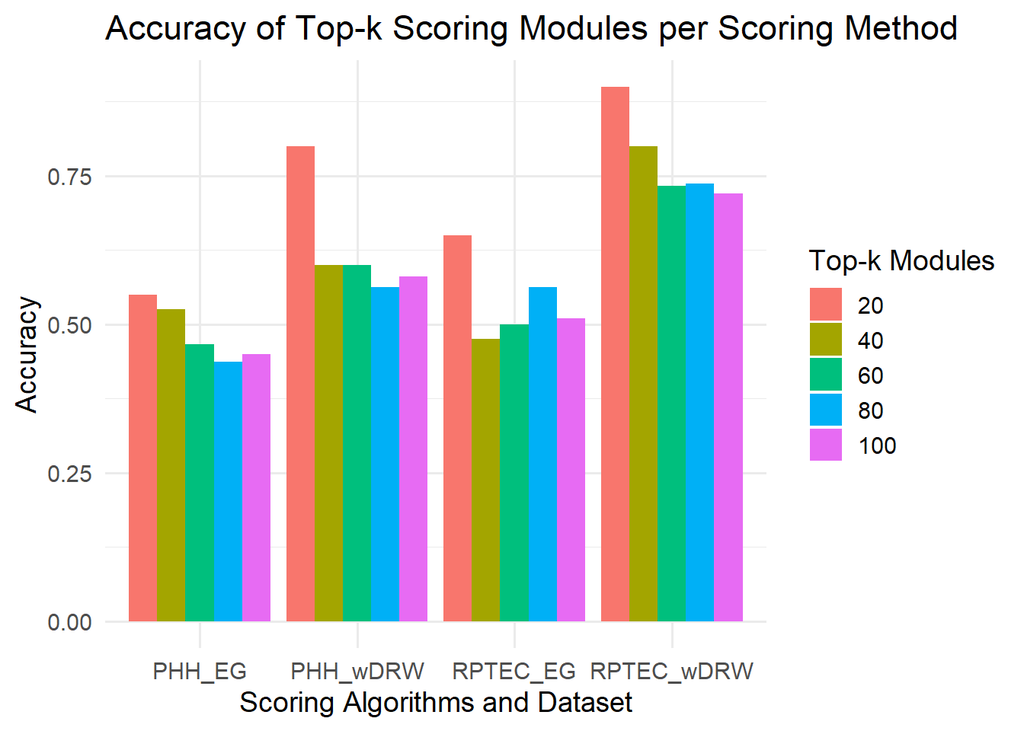

```r
ggplot(accuracy_results, aes(x = dataset, y = accuracy, fill = factor(k))) +
  geom_bar(stat = "identity", position = "dodge") +
  labs(
    title = "Accuracy of Top-k Scoring Modules per Scoring Method",
    x = "Scoring Algorithms and Dataset",
    y = "Accuracy",
    fill = "Top-k Modules"
  ) +
  theme_minimal(base_size = 14)
```